# BOJ

Stefan Angrick

2022-01-04

The `BOJ` package provides an `R` interface to [Bank of Japan](https://www.boj.or.jp/) statistics, specifically the [flat files](https://www.stat-search.boj.or.jp/info/dload_en.html) available on the [BOJ Time-Series Data](https://www.stat-search.boj.or.jp/) portal.

## Import data

To import data, first load the package:

```r
library("BOJ")
```

Next, run the `get_boj_datasets()` function to obtain a list of available data sets:

```r
datasets <- get_boj_datasets()
datasets
```

```
## # A tibble: 17 × 3
##    desc                                    name     url
##    <chr>                                   <chr>    <chr>
##  1 "Corporate Goods Price Index (CGPI)"    cgpi_m_… https://www.stat-search.boj…
##  2 "Producer Price Index using chain-weig… cgpiren… https://www.stat-search.boj…
##  3 "Services Producer Price Index (SPPI)"  sppi_m_… https://www.stat-search.boj…
##  4 "Wholesale Services Price Index"        sppi_q_… https://www.stat-search.boj…
##  5 "Input-Output Price Index of the Manuf… iopi_m_… https://www.stat-search.boj…
##  6 "Flow of Funds"                         fof      https://www.stat-search.boj…
##  7 "Flow of Funds (with name of time-seri… fof2_en  https://www.stat-search.boj…
##  8 "TANKAN"                                co       https://www.stat-search.boj…
##  9 "TANKAN (Fixed Investment and Software… colease  https://www.stat-search.boj…
## 10 "Balance of Payments "                  bp_m_en  https://www.stat-search.boj…
## 11 "Regional Balance of Payments (quarter… regbp_q… https://www.stat-search.boj…
## 12 "International Investment Position (Qu… qiip_q_… https://www.stat-search.boj…
## 13 "International Investment Position (Ca… iip_cy_… https://www.stat-search.boj…
## 14 "BIS International Locational Banking … bis1-1_… https://www.stat-search.boj…
## 15 "BIS International Locational Banking … bis1-2_… https://www.stat-search.boj…
## 16 "BIS International Consolidated Bankin… bis2-1_… https://www.stat-search.boj…
## 17 "BIS International Consolidated Bankin… bis2-2_… https://www.stat-search.boj…
```

The function returns a [tibble](https://tibble.tidyverse.org/) data frame listing the available data sets. The column `url` can be used as input for the function `get_boj()` which downloads, parses and imports the corresponding data.

To import monthly-frequency data on Japan’s [Services Producer Price Index](https://www.boj.or.jp/en/statistics/pi/sppi_2015/index.htm/), run:

```r
sppi <- get_boj(datasets$url[(datasets$name == "sppi_m_en")])
sppi
```

```
## # A tibble: 42,247 × 5
##    code              desc                  struc                 date  obs_value
##    <chr>             <chr>                 <chr>                 <chr>     <dbl>
##  1 PRCS15_5200000000 Services Producer Pr… [Services Producer P… 2015…      99.6
##  2 PRCS15_5200000000 Services Producer Pr… [Services Producer P… 2015…      99.7
##  3 PRCS15_5200000000 Services Producer Pr… [Services Producer P… 2015…     100.
##  4 PRCS15_5200000000 Services Producer Pr… [Services Producer P… 2015…     100
##  5 PRCS15_5200000000 Services Producer Pr… [Services Producer P… 2015…     100.
##  6 PRCS15_5200000000 Services Producer Pr… [Services Producer P… 2015…     100
##  7 PRCS15_5200000000 Services Producer Pr… [Services Producer P… 2015…     100.
##  8 PRCS15_5200000000 Services Producer Pr… [Services Producer P… 2015…     100.
##  9 PRCS15_5200000000 Services Producer Pr… [Services Producer P… 2015…      99.9
## 10 PRCS15_5200000000 Services Producer Pr… [Services Producer P… 2015…      99.9
## # … with 42,237 more rows
```

To plot the data using [ggplot2](https://ggplot2.tidyverse.org), run the following:

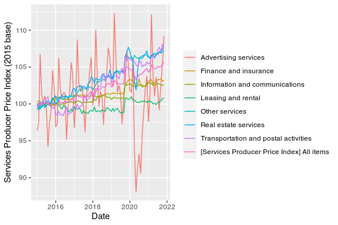

```r
library("dplyr")
library("ggplot2")
library("zoo")

sppi_plot <- subset(sppi, code %in% c("PRCS15_5200000000", "PRCS15_5200010001",
                                      "PRCS15_5200010002", "PRCS15_5200010003",
                                      "PRCS15_5200010004", "PRCS15_5200010005",
                                      "PRCS15_5200010006", "PRCS15_5200010007"))
sppi_plot <- mutate(sppi_plot, date = as.Date(as.yearmon(date, format = "%Y%m")))
sppi_plot <- mutate(sppi_plot, struc = gsub("^Major group/ ", "", struc))
sppi_plot <- subset(sppi_plot, !is.na(obs_value))

ggplot(sppi_plot, aes(x = date, y = obs_value)) +
  geom_line(aes(colour = struc)) +
  labs(x = "Date", y = "Services Producer Price Index (2015 base)") +
  theme(legend.title = element_blank())
```

Note that BOJ data sets come with a number of different time formats. The zoo package (e.g. `as.yearmon()`) should be able to parse most formats.

## Note

This package is in no way officially related to or endorsed by the [Bank of Japan](https://www.boj.or.jp/). It was inspired by the [BIS R package](https://github.com/expersso/BIS). Please don’t abuse the BOJ’s servers with unnecessary calls.